# Week 4 Analysis

Author

Andrew Martinez

Published

January 31, 2025

### Introduction

This analysis explores the pixel data from the 2022 r/place event, focusing on identifying and interpreting the 3 most frequently placed pixel locations. By examining specific pixel coordinates and their color distributions, we uncover interpretations to why these specific pixels were so common.

### Generating Table To See Most Common Pixels!

Table 1: Most Commonly Placed Pixels

| X | Y | Count |
| --- | --- | --- |
| 0 | 0 | 98807 |
| 359 | 564 | 69198 |
| 349 | 564 | 55230 |

While this table poses some intuitive values, such as (0,0), these values are not super descriptive. By providing a simple list like this, only a few “Why’s” or questions may be sufficiently answered. The remaining values are shrouded in mystery, requiring better visualization to uncover these mysterious pixels.

### Investigating (0,0)

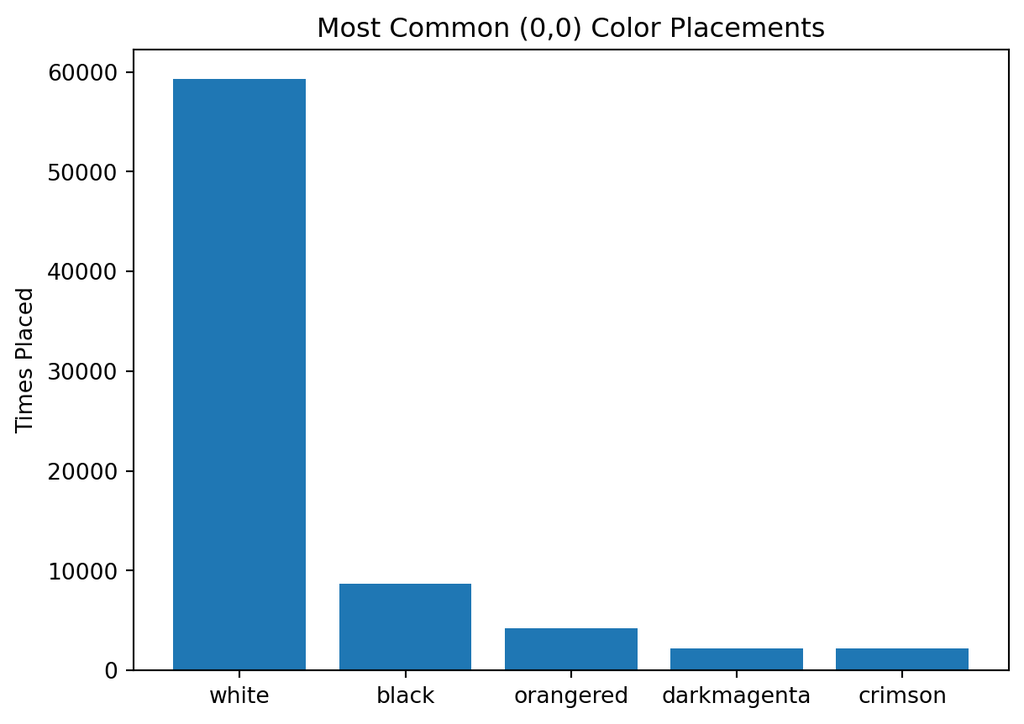

Upon investigation, it seems that by far the most common color placement at (0,0) is white. This leads to a realtively mundane hypothesis, however a hypothesis nonetheless… With the hypothesis being that (0,0) is likely a common pixel for beginning redditors to crowd towards when placing their first pixel. Furthermore, the default color selected being white further supports this theory. Meaning, the reason why this is the most common placement on the Rplace canvas is that new players testing out how it works likely placed white pixels at the top left.

### Investigating (349, 564), (359,564)

[figure not shown]

Through a quick search online I found the Rplace atlas. By scrolling over to (349, 564) and (359,564) I found that these pixels relate to the eyes of this One Piece graphic. While I know what these two pixels represent, further investigation must be done in order to figure out why these two specific pixels were so popular.

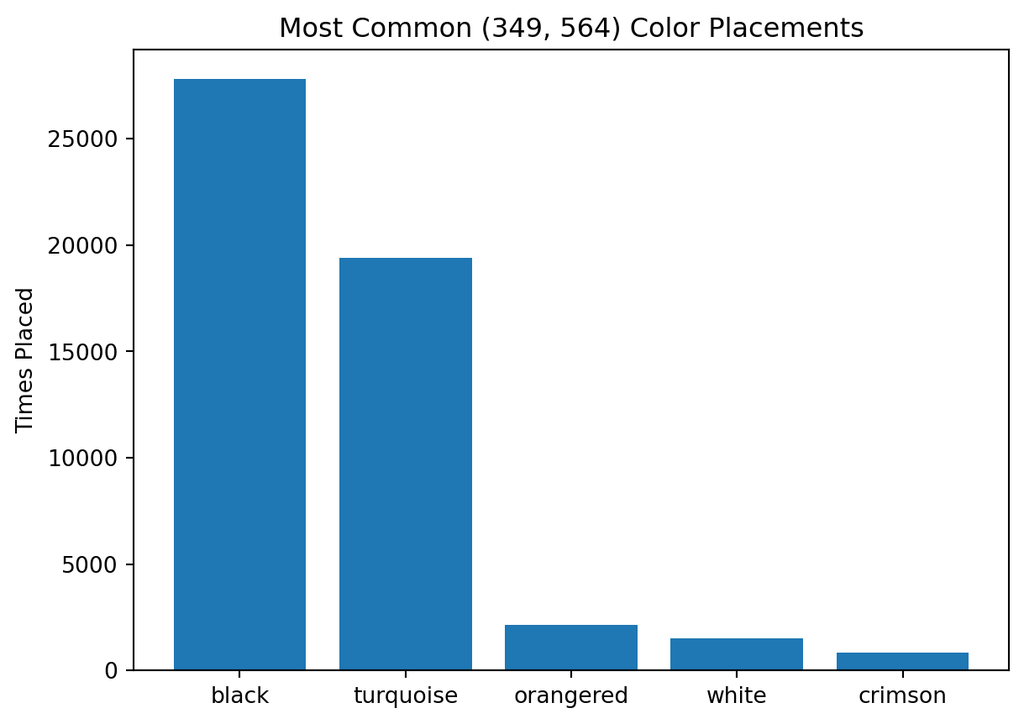

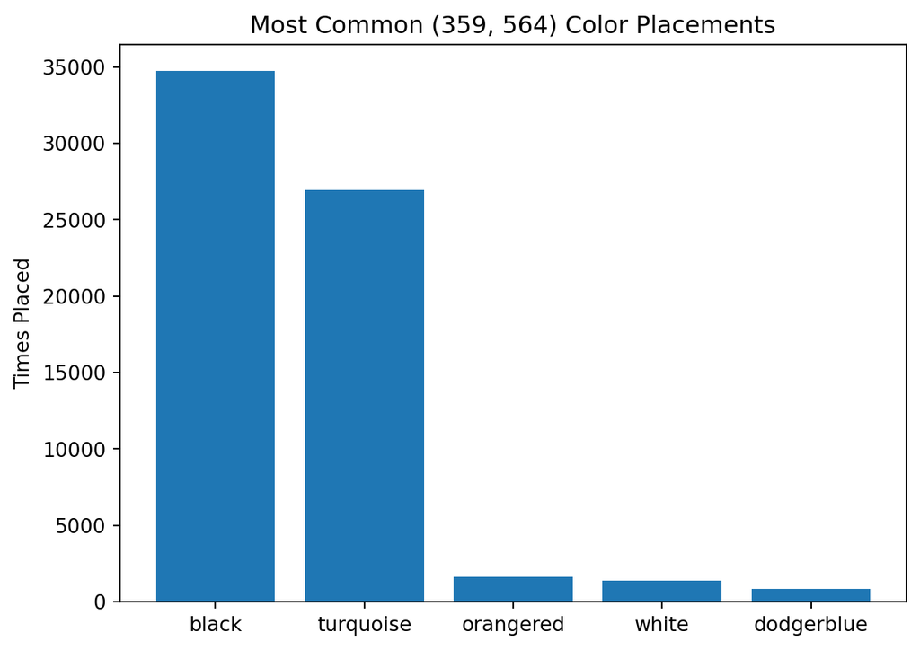

[figure not shown]